# STAT 430: Final Project Report

### Author: Yuan Shi

### Table of content (clickable):

- 1.Dataset Description
- 2.Question of Interest (purpose of web app)
- 3.Testing of the web app
- 4.Conclusion-&-Discussion

## 1. Dataset Description

The data source (2015 Flight Delays and Cancellations) contains three datasets:

#### - Airlines.csv (14 rows and 2 columns)

```
IATA_CODE: Abbreviation of airline companies
AIRLINE: Full name of airline companies
```

#### - Airports.csv (322 rows and 7 columns)

```
IATA_CODE: Abbreviation of airports (note this is different from IATA_CODE in Airlines.csv
AIRPORT: Full name of the airport
CITY: Name of the city which airport is located
STATE: State where the airport is located
COUNTRY: Country where the airport is located
LANTITUDE: lantitude of the airport
longitude: longitude of the airport
```

#### - Flights.csv(5,819,079 rows, 31 columns)

```
AIRLINE: Abbreviation of airline companies
ORIGIN_AIRPORT: airport where the flight is flying from
DESTINATION_AIRPORT: airport where the flight is flying to
YEAR: Year of the record
MONTH: Month of the record
DAY: Date of the record
FLIGHT_NUMBER: Flight identifier
etc....(other columns are not very revalent to our studies)
```

The **ER diagram** I created **below** can show the meta data relationship, which can be used to join tables and data aggregation: (note the code is used to output image in html format)

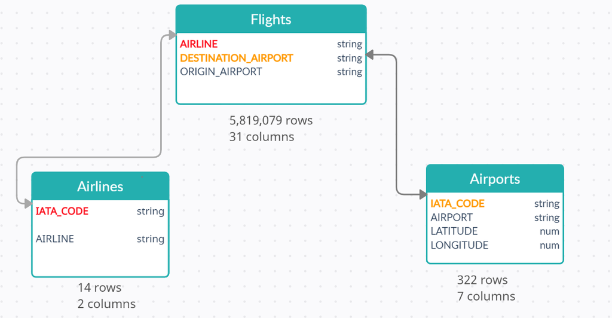

```python
import base64, io, IPython
from PIL import Image as PILImage

image = PILImage.open('/Users/ayyoki/Desktop/stat430/ER.png')

output = io.BytesIO()
image.save(output, format='PNG')
encoded_string = base64.b64encode(output.getvalue()).decode()

html = '<img src="data:…"/>'.format(encoded_string)
IPython.display.HTML(html)
```

**NOTE**: because flgiths are usually two-way flight (verified), the same flight usually have the fixed origin airport and destination airport, so both can be used as primary key to join Airports table.

## 2. Question of Interest (Purpose of the web app)

The goal of our web app is:  
**For each airline that the user selects, plot a graph of the US map with points on the locations of airports that this airline flies to with an indicator on the number of flights coming in/out of that airport by the selected airline (size of the point or color of the point, etc.)**

Expected User input: Airline company they are interested to check  
Expected Output: A US map with plot that indicates the number of flights from the selected airline company across the airports in the US

## 3. Testing of web app

### Test1: Only airline in Champaign-Urbana - MQ (American Eagle Airlines)

```python
## The code is used to extract expexted outcome of the test
import pandas as pd
import warnings
warnings.filterwarnings("ignore")

airlines = pd.read_csv('airlines.csv')
flights = pd.read_csv('flights.csv')
airports = pd.read_csv('airports.csv')

flights[flights.DESTINATION_AIRPORT=='CMI']['AIRLINE'].unique()
```

```
array(['MQ'], dtype=object)
```

```python
### number of flights arrived at CMI
sum(flights.DESTINATION_AIRPORT=='CMI')
```

```
2115
```

So, as shown above, the only airline fly to/from Champaign/Urbana is the American Eagle Airline(MQ), it is also true in our app, with exact same number of flights.

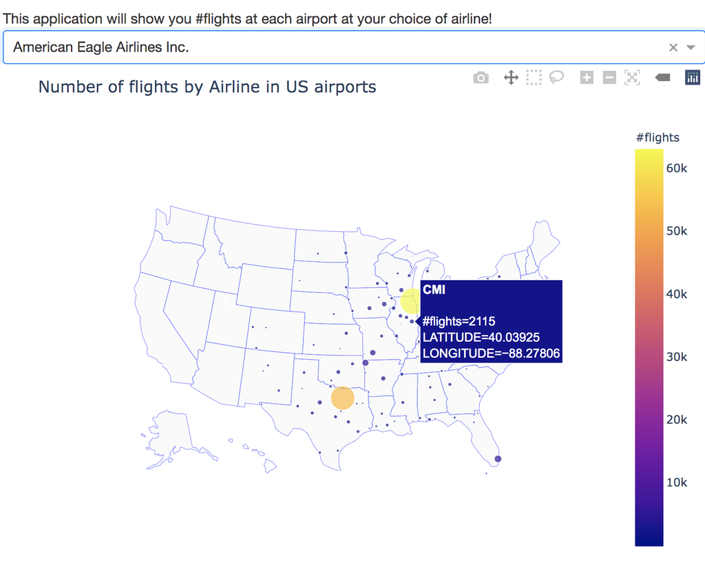

```python
image = PILImage.open('/Users/ayyoki/Desktop/stat430/test1.png')

output = io.BytesIO()
image.save(output, format='PNG')
encoded_string = base64.b64encode(output.getvalue()).decode()

html = '<img src="data:…"/>'.format(encoded_string)
IPython.display.HTML(html)
```

### Test2: Hawaiian Airlines

It is common know and most of Hawaiian Airlines's flights departed and fly to Hawaii, let's see if our app shows that:

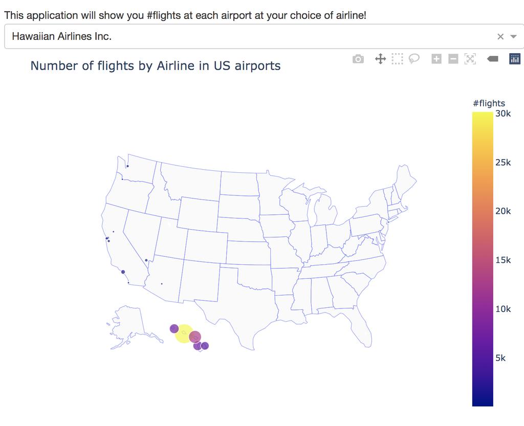

```python
image = PILImage.open('/Users/ayyoki/Desktop/stat430/test2.png')

output = io.BytesIO()
image.save(output, format='PNG')
encoded_string = base64.b64encode(output.getvalue()).decode()

html = '<img src="data:…"/>'.format(encoded_string)
IPython.display.HTML(html)
```

As we can see from our app, most flights from Hawaiian Airlines fly to/from Hawaii, just as we expected.

### 4. Conclusion & Discussion

In conclusion, the web app I made gives the users the option to select an airline company that they're interested in, and it will show them the number of flgihts it fly to/from across all the airport in the US by using various size of bullets with different color, which are easy to be recognized by eyes.  
In which case, I think the web app does what it is designed to do - anwered our question of interest.

However, there is still room for improvements, given this web app is a simple one.

Here are some suggestions of future work:

1. Could explore new features of the app, i.e., draw a line between the origin airport and the destination airport.
2. Could evaluate and introduce users which airports have the longest delay time by airline.